# Customer Segmentation

## Problem Definition

Kira Plastinina is a Russian brand that is sold through a defunct chain of retail stores in Russia, Ukraine, Kazakhstan, Belarus, China, Philippines, and Armenia. The brand’s Sales and Marketing team would like to understand their customer’s behavior from data that they have collected over the past year. More specifically, they would like to learn the characteristics of customer groups.

## Data Sourcing

Data being used in this study was provided by Moringa School

**Data Description**

- The dataset consists of 10 numerical and 8 categorical attributes.
- The **Revenue** attribute can be used as the **class label**.
- “Administrative”, “Administrative Duration”, “Informational”, “Informational Duration”, “Product Related” and “Product Related Duration” represents the number of different types of pages visited by the visitor in that session and total time spent in each of these page categories. The values of these features are derived from the URL information of the pages visited by the user and updated in real-time when a user takes an action, e.g. moving from one page to another.

**Metrics Measured by Google Analytics**

1. The value of the **Bounce Rate** feature for a web page refers to the percentage of visitors who enter the site from that page and then leave (“bounce”) without triggering any other requests to the analytics server during that session.
2. The value of the **Exit Rate** feature for a specific web page is calculated as for all pageviews to the page, the percentage that was the last in the session.
3. The **Page Value** feature represents the average value for a web page that a user visited before completing an e-commerce transaction.
- The **Special Day** feature indicates the closeness of the site visiting time to a specific special day (e.g. Mother’s Day, Valentine’s Day) in which the sessions are more likely to be finalized with the transaction. The value of this attribute is determined by considering the dynamics of e-commerce such as the duration between the order date and delivery date. For example, for Valentina’s day, this value takes a nonzero value between February 2 and February 12, zero before and after this date unless it is close to another special day, and its maximum value of 1 on February 8.
- The dataset also includes the operating system, browser, region, traffic type, visitor type as returning or new visitor, a Boolean value indicating whether the date of the visit is weekend, and month of the year.

## Reading/Checking data

```r
#Loading the data
df <-read.csv("http://bit.ly/EcommerceCustomersDataset", header = TRUE)
#Showing head of data
head(df)
```

```
##   Administrative Administrative_Duration Informational Informational_Duration
## 1              0                       0             0                      0
## 2              0                       0             0                      0
## 3              0                      -1             0                     -1
## 4              0                       0             0                      0
## 5              0                       0             0                      0
## 6              0                       0             0                      0
##   ProductRelated ProductRelated_Duration BounceRates ExitRates PageValues
## 1              1                0.000000  0.20000000 0.2000000          0
## 2              2               64.000000  0.00000000 0.1000000          0
## 3              1               -1.000000  0.20000000 0.2000000          0
## 4              2                2.666667  0.05000000 0.1400000          0
## 5             10              627.500000  0.02000000 0.0500000          0
## 6             19              154.216667  0.01578947 0.0245614          0
##   SpecialDay Month OperatingSystems Browser Region TrafficType
## 1          0   Feb                1       1      1           1
## 2          0   Feb                2       2      1           2
## 3          0   Feb                4       1      9           3
## 4          0   Feb                3       2      2           4
## 5          0   Feb                3       3      1           4
## 6          0   Feb                2       2      1           3
##         VisitorType Weekend Revenue
## 1 Returning_Visitor   FALSE   FALSE
## 2 Returning_Visitor   FALSE   FALSE
## 3 Returning_Visitor   FALSE   FALSE
## 4 Returning_Visitor   FALSE   FALSE
## 5 Returning_Visitor    TRUE   FALSE
## 6 Returning_Visitor   FALSE   FALSE
```

```r
#Checking for dimensions and class types
str(df)
```

```
## 'data.frame':    12330 obs. of  18 variables:
##  $ Administrative         : int  0 0 0 0 0 0 0 1 0 0 ...
##  $ Administrative_Duration: num  0 0 -1 0 0 0 -1 -1 0 0 ...
##  $ Informational          : int  0 0 0 0 0 0 0 0 0 0 ...
##  $ Informational_Duration : num  0 0 -1 0 0 0 -1 -1 0 0 ...
##  $ ProductRelated         : int  1 2 1 2 10 19 1 1 2 3 ...
##  $ ProductRelated_Duration: num  0 64 -1 2.67 627.5 ...
##  $ BounceRates            : num  0.2 0 0.2 0.05 0.02 ...
##  $ ExitRates              : num  0.2 0.1 0.2 0.14 0.05 ...
##  $ PageValues             : num  0 0 0 0 0 0 0 0 0 0 ...
##  $ SpecialDay             : num  0 0 0 0 0 0 0.4 0 0.8 0.4 ...
##  $ Month                  : chr  "Feb" "Feb" "Feb" "Feb" ...
##  $ OperatingSystems       : int  1 2 4 3 3 2 2 1 2 2 ...
##  $ Browser                : int  1 2 1 2 3 2 4 2 2 4 ...
##  $ Region                 : int  1 1 9 2 1 1 3 1 2 1 ...
##  $ TrafficType            : int  1 2 3 4 4 3 3 5 3 2 ...
##  $ VisitorType            : chr  "Returning_Visitor" "Returning_Visitor" "Returning_Visitor" "Returning_Visitor" ...
##  $ Weekend                : logi  FALSE FALSE FALSE FALSE TRUE FALSE ...
##  $ Revenue                : logi  FALSE FALSE FALSE FALSE FALSE FALSE ...
```

Data has 12330 observations(rows) and 18 variables(columns) We have integers, numerics , character and logical features in our dataset.

```r
summary((df))
```

```
##  Administrative   Administrative_Duration Informational
##  Min.   : 0.000   Min.   :  -1.00         Min.   : 0.000
##  1st Qu.: 0.000   1st Qu.:   0.00         1st Qu.: 0.000
##  Median : 1.000   Median :   8.00         Median : 0.000
##  Mean   : 2.318   Mean   :  80.91         Mean   : 0.504
##  3rd Qu.: 4.000   3rd Qu.:  93.50         3rd Qu.: 0.000
##  Max.   :27.000   Max.   :3398.75         Max.   :24.000
##  NA's   :14       NA's   :14              NA's   :14
##  Informational_Duration ProductRelated   ProductRelated_Duration
##  Min.   :  -1.00        Min.   :  0.00   Min.   :   -1.0
##  1st Qu.:   0.00        1st Qu.:  7.00   1st Qu.:  185.0
##  Median :   0.00        Median : 18.00   Median :  599.8
##  Mean   :  34.51        Mean   : 31.76   Mean   : 1196.0
##  3rd Qu.:   0.00        3rd Qu.: 38.00   3rd Qu.: 1466.5
##  Max.   :2549.38        Max.   :705.00   Max.   :63973.5
##  NA's   :14             NA's   :14       NA's   :14
##   BounceRates         ExitRates         PageValues        SpecialDay
##  Min.   :0.000000   Min.   :0.00000   Min.   :  0.000   Min.   :0.00000
##  1st Qu.:0.000000   1st Qu.:0.01429   1st Qu.:  0.000   1st Qu.:0.00000
##  Median :0.003119   Median :0.02512   Median :  0.000   Median :0.00000
##  Mean   :0.022152   Mean   :0.04300   Mean   :  5.889   Mean   :0.06143
##  3rd Qu.:0.016684   3rd Qu.:0.05000   3rd Qu.:  0.000   3rd Qu.:0.00000
##  Max.   :0.200000   Max.   :0.20000   Max.   :361.764   Max.   :1.00000
##  NA's   :14         NA's   :14
##     Month           OperatingSystems    Browser           Region
##  Length:12330       Min.   :1.000    Min.   : 1.000   Min.   :1.000
##  Class :character   1st Qu.:2.000    1st Qu.: 2.000   1st Qu.:1.000
##  Mode  :character   Median :2.000    Median : 2.000   Median :3.000
##                     Mean   :2.124    Mean   : 2.357   Mean   :3.147
##                     3rd Qu.:3.000    3rd Qu.: 2.000   3rd Qu.:4.000
##                     Max.   :8.000    Max.   :13.000   Max.   :9.000
##
##   TrafficType    VisitorType         Weekend         Revenue
##  Min.   : 1.00   Length:12330       Mode :logical   Mode :logical
##  1st Qu.: 2.00   Class :character   FALSE:9462      FALSE:10422
##  Median : 2.00   Mode  :character   TRUE :2868      TRUE :1908
##  Mean   : 4.07
##  3rd Qu.: 4.00
##  Max.   :20.00
##
```

## Data Cleaning

```r
# Changing the type of the loaded dataset to a dataframe
df = as.data.frame(df)

# Cleaning column names, by making them uniform
colnames(df) = tolower(colnames(df))
```

```r
#Checking for duplicated rows
duplicated_rows <- df[duplicated(df),]
dim(duplicated_rows)
```

```
## [1] 119  18
```

```r
#Dropping duplicated rows
df <- df[!duplicated(df), ]
dim(df)
```

```
## [1] 12211    18
```

```r
#Checking for missing values
colSums(is.na(df))
```

```
##          administrative administrative_duration           informational
##                      12                      12                      12
##  informational_duration          productrelated productrelated_duration
##                      12                      12                      12
##             bouncerates               exitrates              pagevalues
##                      12                      12                       0
##              specialday                   month        operatingsystems
##                       0                       0                       0
##                 browser                  region             traffictype
##                       0                       0                       0
##             visitortype                 weekend                 revenue
##                       0                       0                       0
```

Since this data is generated from a website, it doesn’t make sense that we have missing values. We will therefore drop this values.

```r
#Dropping  missing values
df = na.omit(df)
colSums(is.na(df))
```

```
##          administrative administrative_duration           informational
##                       0                       0                       0
##  informational_duration          productrelated productrelated_duration
##                       0                       0                       0
##             bouncerates               exitrates              pagevalues
##                       0                       0                       0
##              specialday                   month        operatingsystems
##                       0                       0                       0
##                 browser                  region             traffictype
##                       0                       0                       0
##             visitortype                 weekend                 revenue
##                       0                       0                       0
```

```r
dim(df)
```

```
## [1] 12199    18
```

```r
library(magrittr)
library(tidyverse)
cat_cols = c('month', 'operatingsystems',   'browser',  'region',   'traffictype', 'visitortype')

# Changing columns to factors
df[,cat_cols] %<>% lapply(function(x) as.factor(as.character(x)))
str(df)
```

```
## 'data.frame':    12199 obs. of  18 variables:
##  $ administrative         : int  0 0 0 0 0 0 0 1 0 0 ...
##  $ administrative_duration: num  0 0 -1 0 0 0 -1 -1 0 0 ...
##  $ informational          : int  0 0 0 0 0 0 0 0 0 0 ...
##  $ informational_duration : num  0 0 -1 0 0 0 -1 -1 0 0 ...
##  $ productrelated         : int  1 2 1 2 10 19 1 1 2 3 ...
##  $ productrelated_duration: num  0 64 -1 2.67 627.5 ...
##  $ bouncerates            : num  0.2 0 0.2 0.05 0.02 ...
##  $ exitrates              : num  0.2 0.1 0.2 0.14 0.05 ...
##  $ pagevalues             : num  0 0 0 0 0 0 0 0 0 0 ...
##  $ specialday             : num  0 0 0 0 0 0 0.4 0 0.8 0.4 ...
##  $ month                  : Factor w/ 10 levels "Aug","Dec","Feb",..: 3 3 3 3 3 3 3 3 3 3 ...
##  $ operatingsystems       : Factor w/ 8 levels "1","2","3","4",..: 1 2 4 3 3 2 2 1 2 2 ...
##  $ browser                : Factor w/ 13 levels "1","10","11",..: 1 6 1 6 7 6 8 6 6 8 ...
##  $ region                 : Factor w/ 9 levels "1","2","3","4",..: 1 1 9 2 1 1 3 1 2 1 ...
##  $ traffictype            : Factor w/ 20 levels "1","10","11",..: 1 12 14 15 15 14 14 16 14 12 ...
##  $ visitortype            : Factor w/ 3 levels "New_Visitor",..: 3 3 3 3 3 3 3 3 3 3 ...
##  $ weekend                : logi  FALSE FALSE FALSE FALSE TRUE FALSE ...
##  $ revenue                : logi  FALSE FALSE FALSE FALSE FALSE FALSE ...
##  - attr(*, "na.action")= 'omit' Named int [1:12] 1050 1116 1117 1118 1119 1443 1444 1445 1446 1996 ...
##   ..- attr(*, "names")= chr [1:12] "1066" "1133" "1134" "1135" ...
```

```r
head(df)
```

```
##   administrative administrative_duration informational informational_duration
## 1              0                       0             0                      0
## 2              0                       0             0                      0
## 3              0                      -1             0                     -1
## 4              0                       0             0                      0
## 5              0                       0             0                      0
## 6              0                       0             0                      0
##   productrelated productrelated_duration bouncerates exitrates pagevalues
## 1              1                0.000000  0.20000000 0.2000000          0
## 2              2               64.000000  0.00000000 0.1000000          0
## 3              1               -1.000000  0.20000000 0.2000000          0
## 4              2                2.666667  0.05000000 0.1400000          0
## 5             10              627.500000  0.02000000 0.0500000          0
## 6             19              154.216667  0.01578947 0.0245614          0
##   specialday month operatingsystems browser region traffictype
## 1          0   Feb                1       1      1           1
## 2          0   Feb                2       2      1           2
## 3          0   Feb                4       1      9           3
## 4          0   Feb                3       2      2           4
## 5          0   Feb                3       3      1           4
## 6          0   Feb                2       2      1           3
##         visitortype weekend revenue
## 1 Returning_Visitor   FALSE   FALSE
## 2 Returning_Visitor   FALSE   FALSE
## 3 Returning_Visitor   FALSE   FALSE
## 4 Returning_Visitor   FALSE   FALSE
## 5 Returning_Visitor    TRUE   FALSE
## 6 Returning_Visitor   FALSE   FALSE
```

```r
#Checking for unique values to see whether we have any abnormal values
#uniq <- df %<>% lapply(function(x)unique(x)))
#uniq
```

```r
colnames(df)
```

```
##  [1] "administrative"          "administrative_duration"
##  [3] "informational"           "informational_duration"
##  [5] "productrelated"          "productrelated_duration"
##  [7] "bouncerates"             "exitrates"
##  [9] "pagevalues"              "specialday"
## [11] "month"                   "operatingsystems"
## [13] "browser"                 "region"
## [15] "traffictype"             "visitortype"
## [17] "weekend"                 "revenue"
```

```r
#Checking for outliers
#First we select numeric columns
nums <- subset(df, select = -c(specialday, month, operatingsystems,browser, region, traffictype, visitortype,weekend,revenue))
head(nums)
```

```
##   administrative administrative_duration informational informational_duration
## 1              0                       0             0                      0
## 2              0                       0             0                      0
## 3              0                      -1             0                     -1
## 4              0                       0             0                      0
## 5              0                       0             0                      0
## 6              0                       0             0                      0
##   productrelated productrelated_duration bouncerates exitrates pagevalues
## 1              1                0.000000  0.20000000 0.2000000          0
## 2              2               64.000000  0.00000000 0.1000000          0
## 3              1               -1.000000  0.20000000 0.2000000          0
## 4              2                2.666667  0.05000000 0.1400000          0
## 5             10              627.500000  0.02000000 0.0500000          0
## 6             19              154.216667  0.01578947 0.0245614          0
```

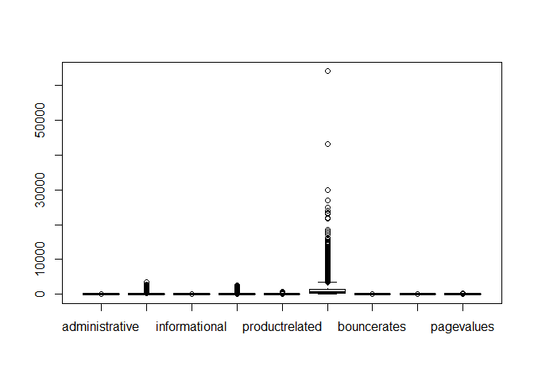

```r
boxplot(nums)
```

All of the numerical columns have outliers. It is also important to note that a few of this have negative values. But since we are dealing with customers and reatails have all sort of customers who have different values and capabilities we will leave these outliers as they are. This way we will be able to capture this groups when grouping the customers.

## Data Exploration

### 1. Distributions of numerical values

```r
library(ggplot2)
library(psych)
#Central tendency
describe(nums)
```

```
##                         vars     n    mean      sd median trimmed    mad min
## administrative             1 12199    2.34    3.33   1.00    1.66   1.48   0
## administrative_duration    2 12199   81.68  177.53   9.00   42.87  13.34  -1
## informational              3 12199    0.51    1.28   0.00    0.18   0.00   0
## informational_duration     4 12199   34.84  141.46   0.00    3.73   0.00  -1
## productrelated             5 12199   32.06   44.60  18.00   23.06  19.27   0
## productrelated_duration    6 12199 1207.51 1919.93 609.54  832.36 745.12  -1
## bouncerates                7 12199    0.02    0.05   0.00    0.01   0.00   0
## exitrates                  8 12199    0.04    0.05   0.03    0.03   0.02   0
## pagevalues                 9 12199    5.95   18.66   0.00    1.33   0.00   0
##                              max    range skew kurtosis    se
## administrative             27.00    27.00 1.95     4.63  0.03
## administrative_duration  3398.75  3399.75 5.59    50.09  1.61
## informational              24.00    24.00 4.01    26.64  0.01
## informational_duration   2549.38  2550.38 7.54    75.45  1.28
## productrelated            705.00   705.00 4.33    31.04  0.40
## productrelated_duration 63973.52 63974.52 7.25   136.57 17.38
## bouncerates                 0.20     0.20 3.15     9.25  0.00
## exitrates                   0.20     0.20 2.23     4.62  0.00
## pagevalues                361.76   361.76 6.35    64.93  0.17
```

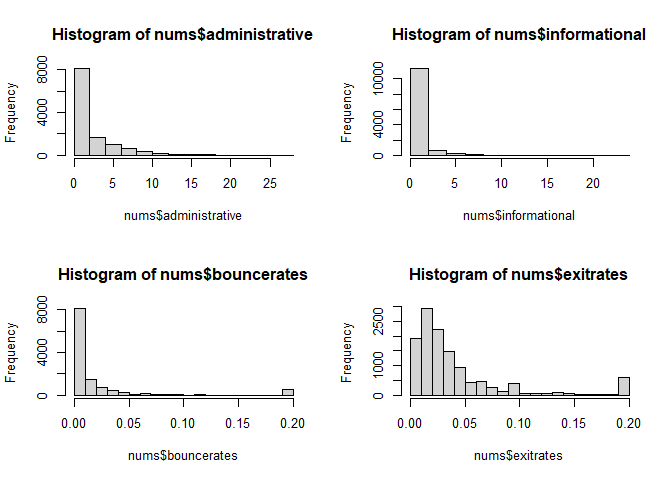

```r
#Plotting histograms to show distribution of variables
par(mfrow = c(2, 2))
hist(nums$administrative)
hist(nums$informational)
hist(nums$bouncerates)
hist(nums$exitrates)
```

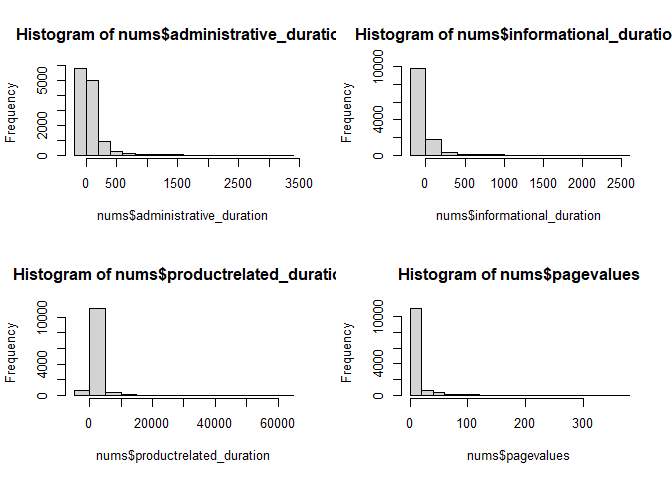

```r
par(mfrow = c(2, 2))
hist(nums$administrative_duration)
hist(nums$informational_duration)
hist(nums$productrelated_duration)
hist(nums$pagevalues)
```

**Conclusions** From the central tendency we see that: 1. All variables have a sample size of 12199 2. Product related duration have the largest figures and range, meaning peole visiting the website spend alot of time in the product related page 3. People also spend a considerable amount of time checking on the administration 4. People spend the least of time checking out the information related page

### 2. Categorical data Analysis

```r
#install.packages("ggpubr")
library(ggpubr)
```

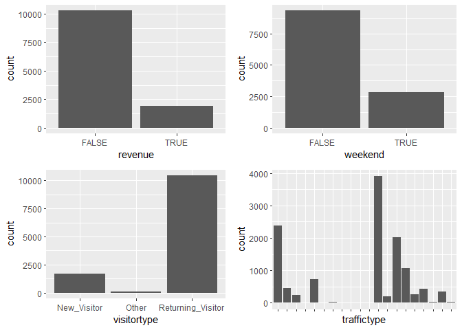

```r
#Did most traffic generate any revenue?
r <- ggplot(data = df) +
  geom_bar(mapping = aes(x = revenue))
#Was traffic high on weekends or not?
w <- ggplot(data = df) +
  geom_bar(mapping = aes(x = weekend))
#What group of visitors frequented the website?
v <-ggplot(data = df) +
  geom_bar(mapping = aes(x = visitortype))
#What traffic type was mostly used?
t <- ggplot(data = df) +
  geom_bar(mapping = aes(x = traffictype))
ggarrange(r, w, v, t + rremove("x.text"),
          ncol = 2, nrow = 2)
```

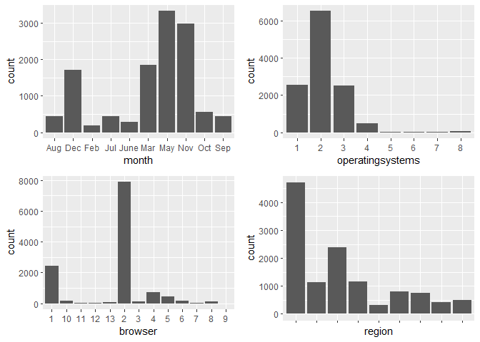

```r
#Which months had the highest traffic
m <- ggplot(data = df) +
  geom_bar(mapping = aes(x = month))
#Distribution of operating systems on traffic
o <- ggplot(data = df) +
  geom_bar(mapping = aes(x = operatingsystems))
#Browser distribution
b <-ggplot(data = df) +
  geom_bar(mapping = aes(x = browser))
#Which regions trafficked the website the most?
r <- ggplot(data = df) +
  geom_bar(mapping = aes(x = region))
ggarrange(m, o, b, r + rremove("x.text"),
          ncol = 2, nrow = 2)
```

**Conclusions** 1. Most of the traffic in the website doesn’t generate any revenue 2. There is more traffic on weekdays than weekends, but the traffic on weekends is relatively high considering that weekends consist of only 2 days per week. 3. Most of the people visiting the website are returning visitors, only a small percentage are new 4. There is alot of traffic in the website in May, November, March and Dec 5. Almost 5000 of the traffic in the website for the year was from region 1, around 2,300 from region 3 and the other regions ranging from 1000 to 300 individuals.

### 3. Bivariate Analysis

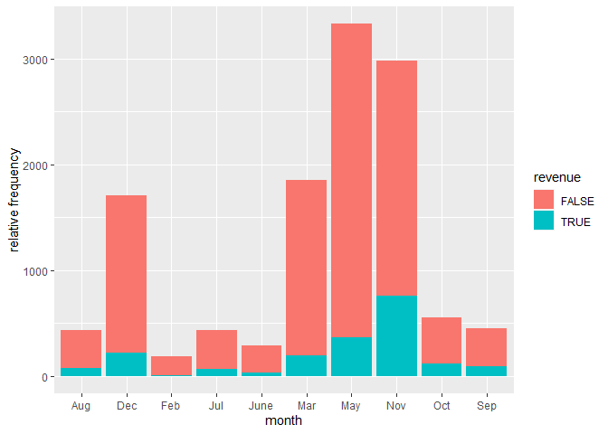

```r
#Revenue generation per month
df %>%
  ggplot() +
  aes(x = month, revenue = ..count../nrow(df), fill = revenue) +
  geom_bar() +
  ylab("relative frequency")
```

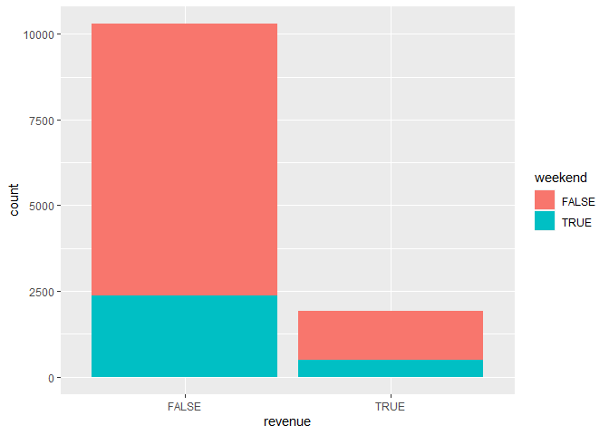

```r
#Checking how weekends generated revenue as compared to weekdays
ggplot(df,
       aes(x = revenue,
           fill = weekend)) +
  geom_bar(position = "stack")
```

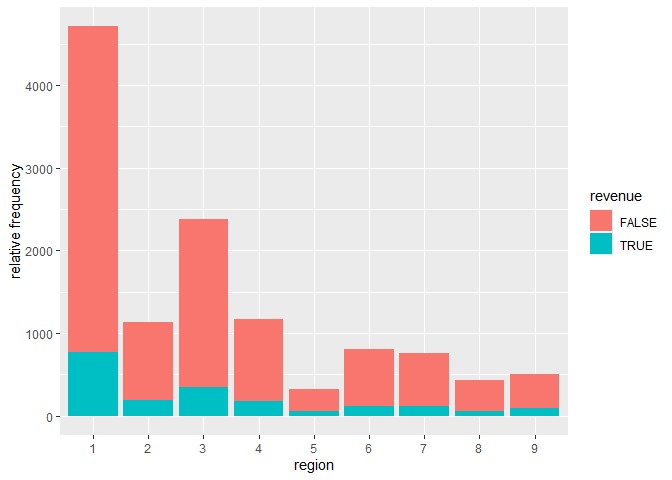

```r
df %>%
  ggplot() +
  aes(x = region, revenue = ..count../nrow(df), fill = revenue) +
  geom_bar() +
  ylab("relative frequency")
```

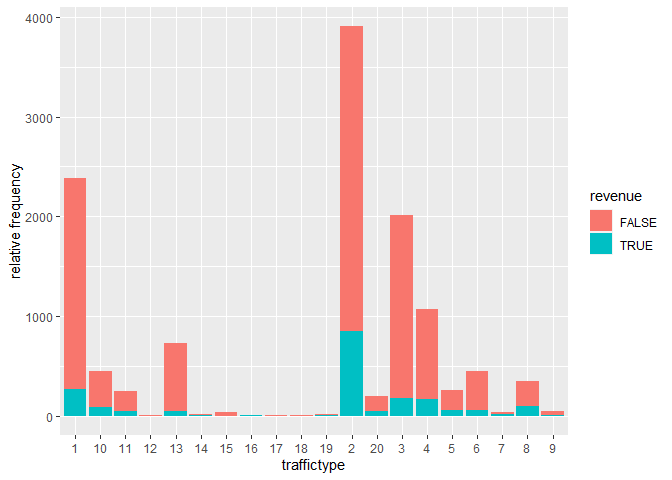

```r
df %>%
  ggplot() +
  aes(x = traffictype, revenue = ..count../nrow(df), fill = revenue) +
  geom_bar() +
  ylab("relative frequency")
```

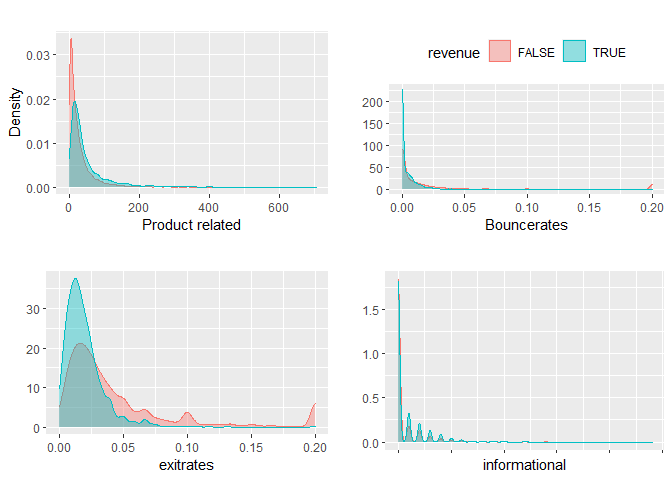

```r
#Checking the distribution of different variables in relation to revenue
options(repr.plot.width = 11, repr.plot.height = 5)
p1 = ggplot(df, aes(productrelated, col = revenue)) +
  geom_density(aes(fill = revenue), alpha = 0.4) +
  labs(x = 'Product related', y = 'Density', title = '') +
  theme(legend.position = 'none',
       plot.title = element_text(size = 12))

p2 = ggplot(df, aes(bouncerates, col = revenue)) +
  geom_density(aes(fill = revenue), alpha = 0.4) +
  labs(x = 'Bouncerates', y = '', title = '') +
  theme(legend.position = 'top')

p3 = ggplot(df, aes(exitrates, col = revenue)) +
  geom_density(aes(fill = revenue), alpha = 0.4) +
  labs(x = 'exitrates', y = '', title = '') +
  theme(legend.position = 'none',
       plot.title = element_text(size = 12))


p4 = ggplot(df, aes(informational, col = revenue)) +
  geom_density(aes(fill = revenue), alpha = 0.4) +
  labs(x = 'informational', y = '', title = '') +
  theme(legend.position = 'none',
       plot.title = element_text(size = 12))


ggarrange(p1, p2, p3, p4 + rremove("x.text"),
          ncol = 2, nrow = 2)
```

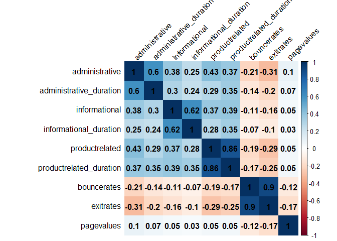

```r
install.packages("corrplot")
library(corrplot)
#Get the correlation matrix
res = cor(nums)
#Plotting a correlation plot

corrplot(res, method="color",addCoef.col = "black",
         tl.col="black", tl.srt=45)
```

**Conclusions** * There is a strong positive correlation between a page and the duration taken by visitors on that page, for example product related and product related duration * There is also a strong correlation between exitrates and bounce rates

## Implement the Solution

### Feature Engineering

```r
#converting the variable weekend to a dummy
#with weekend being a ‘1’ and a weekday being a ‘0’
mod.data <- df %>%
  mutate(Weekend_binary = ifelse(weekend == "FALSE",0,1))
head(mod.data)
```

```
##   administrative administrative_duration informational informational_duration
## 1              0                       0             0                      0
## 2              0                       0             0                      0
## 3              0                      -1             0                     -1
## 4              0                       0             0                      0
## 5              0                       0             0                      0
## 6              0                       0             0                      0
##   productrelated productrelated_duration bouncerates exitrates pagevalues
## 1              1                0.000000  0.20000000 0.2000000          0
## 2              2               64.000000  0.00000000 0.1000000          0
## 3              1               -1.000000  0.20000000 0.2000000          0
## 4              2                2.666667  0.05000000 0.1400000          0
## 5             10              627.500000  0.02000000 0.0500000          0
## 6             19              154.216667  0.01578947 0.0245614          0
##   specialday month operatingsystems browser region traffictype
## 1          0   Feb                1       1      1           1
## 2          0   Feb                2       2      1           2
## 3          0   Feb                4       1      9           3
## 4          0   Feb                3       2      2           4
## 5          0   Feb                3       3      1           4
## 6          0   Feb                2       2      1           3
##         visitortype weekend revenue Weekend_binary
## 1 Returning_Visitor   FALSE   FALSE              0
## 2 Returning_Visitor   FALSE   FALSE              0
## 3 Returning_Visitor   FALSE   FALSE              0
## 4 Returning_Visitor   FALSE   FALSE              0
## 5 Returning_Visitor    TRUE   FALSE              1
## 6 Returning_Visitor   FALSE   FALSE              0
```

```r
#Removing the target column and weekday column
mod <- subset(mod.data, select = -c(weekend))
#Separating features from target
mod.new <- mod[, c(1,2,3,4,5,6,7,8,9,10)]
mod.class <- mod[, "revenue"]
head(mod.new)
```

```
##   administrative administrative_duration informational informational_duration
## 1              0                       0             0                      0
## 2              0                       0             0                      0
## 3              0                      -1             0                     -1
## 4              0                       0             0                      0
## 5              0                       0             0                      0
## 6              0                       0             0                      0
##   productrelated productrelated_duration bouncerates exitrates pagevalues
## 1              1                0.000000  0.20000000 0.2000000          0
## 2              2               64.000000  0.00000000 0.1000000          0
## 3              1               -1.000000  0.20000000 0.2000000          0
## 4              2                2.666667  0.05000000 0.1400000          0
## 5             10              627.500000  0.02000000 0.0500000          0
## 6             19              154.216667  0.01578947 0.0245614          0
##   specialday
## 1          0
## 2          0
## 3          0
## 4          0
## 5          0
## 6          0
```

```r
#Normalizing data

normalize <- function(x) {
  return ((x - min(x)) / (max(x) - min(x)))
}
## Creating a copy of the original data.
data.mod <- mod.new

## Normalizing our 10 variables.
data.mod$administrative <- normalize(data.mod$administrative)
data.mod$administrative_duration <- normalize(data.mod$administrative_duration)
data.mod$informational <- normalize(data.mod$informational)
data.mod$informational_duration <- normalize(data.mod$informational_duration)
data.mod$productrelated <- normalize(data.mod$productrelated)
data.mod$productrelated_duration <- normalize(data.mod$productrelated_duration)
data.mod$bouncerates <- normalize(data.mod$bouncerates)
data.mod$exitrates <- normalize(data.mod$exitrates)
data.mod$pagevalues <- normalize(data.mod$pagevalues)
data.mod$specialday <- normalize(data.mod$specialday)
head(data.mod)
```

```
##   administrative administrative_duration informational informational_duration
## 1              0            0.0002941393             0           0.0003920992
## 2              0            0.0002941393             0           0.0003920992
## 3              0            0.0000000000             0           0.0000000000
## 4              0            0.0002941393             0           0.0003920992
## 5              0            0.0002941393             0           0.0003920992
## 6              0            0.0002941393             0           0.0003920992
##   productrelated productrelated_duration bouncerates exitrates pagevalues
## 1    0.001418440            1.563122e-05  1.00000000  1.000000          0
## 2    0.002836879            1.016029e-03  0.00000000  0.500000          0
## 3    0.001418440            0.000000e+00  1.00000000  1.000000          0
## 4    0.002836879            5.731448e-05  0.25000000  0.700000          0
## 5    0.014184397            9.824223e-03  0.10000000  0.250000          0
## 6    0.026950355            2.426226e-03  0.07894737  0.122807          0
##   specialday
## 1          0
## 2          0
## 3          0
## 4          0
## 5          0
## 6          0
```

### Modelling

**1. K-Means Clustering**

```r
#Load the packages as follow:


library(factoextra)
library(NbClust)
```

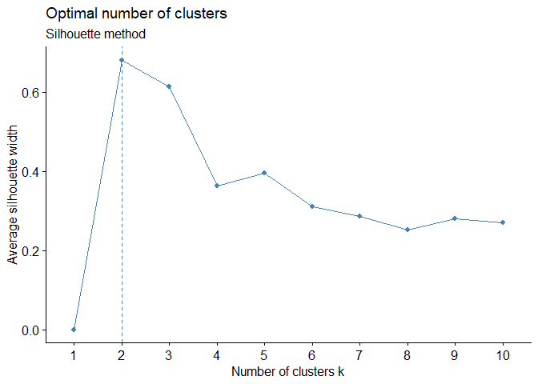

```r
#Getting the optimal number of clusters
# Silhouette method
fviz_nbclust(data.mod, kmeans, method = "silhouette")+
  labs(subtitle = "Silhouette method")
```

```r
#Modelling using centroid = 2
set.seed(5)
model_k <- kmeans(data.mod,2, iter.max = 100)
#Viewing centers of the clusters
model_k$centers
```

```
##   administrative administrative_duration informational informational_duration
## 1    0.093656006            0.0262669218  0.0228950327           0.0151795833
## 2    0.002185662            0.0007844135  0.0007153076           0.0004178465
##   productrelated productrelated_duration bouncerates exitrates pagevalues
## 1    0.048844961             0.020367634  0.04366175 0.1511488 0.01781518
## 2    0.004708855             0.001032834  0.81031289 0.8885226 0.00000000
##   specialday
## 1 0.05710482
## 2 0.12081545
```

```r
model_k$cluster
```

[output not shown]

[output cut: 1863 more lines]

```r
# Previewing the no. of records in each cluster
#
model_k$size
```

```
## [1] 11267   932
```

```r
t1 <- table(model_k$cluster, mod.class)
t1
```

```
##    mod.class
##     FALSE TRUE
##   1  9365 1902
##   2   926    6
```

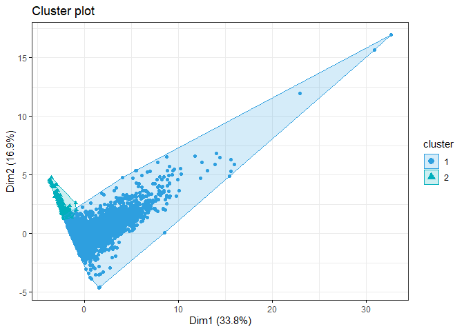

```r
fviz_cluster(model_k, data = data.mod,
             palette = c("#2E9FDF", "#00AFBB", "#E7B800"),
             geom = "point",
             ellipse.type = "convex",
             ggtheme = theme_bw()
             )
```

### Hierarchical Clustering

```r
library(cluster)
library(dendextend)
library(purrr)
```

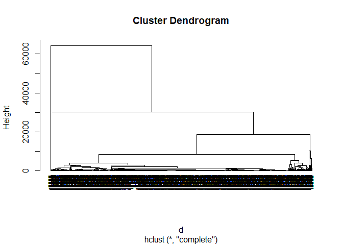

```r
# Dissimilarity matrix

d <- dist(mod.new, method = "euclidean")

# Hierarchical clustering using Complete Linkage
hc1 <- hclust(d, method = "complete" )

# Plot the obtained dendrogram
plot(hc1, cex = 0.6, hang = -1)
```

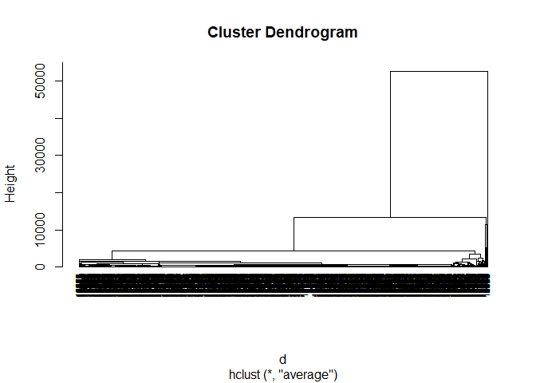

```r
# Hierarchical clustering using Average Linkage
hc2 <- hclust(d, method = "average" )

# Plot the obtained dendrogram
plot(hc2, cex = 0.6, hang = -1)
```

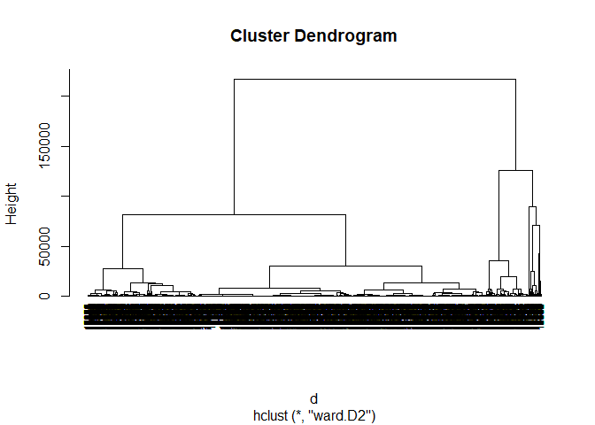

```r
# Hierarchical clustering using Average Linkage
hc3 <- hclust(d, method = "ward.D2" )

# Plot the obtained dendrogram
plot(hc3, cex = 0.6, hang = -1)
```

## Conclusion

It would be advised that the Kira Plastinina marketers should use the K Means clustering for Customer Segmentation since the clusters are clearer. * But, it would also be great to use DBSCAN for this study to be able to classify potential customers and also the outliers.